# Time Series HW13

B082040005 高念慈

2023-05-22

## 2.

Consider the monthly simple returns of Intel stock from January 1973 to  
December 2008 in m-intc7308.txt.Transform the returns into log returns.  
Build a GARCH model for the transformed series and compute 1-step- to  
5-step-ahead volatility forecasts at the forecast origin December 2008.

```r
intc = read.table("https://faculty.chicagobooth.edu/-/media/faculty/ruey-s-tsay/teaching/fts3/m-intc7308.txt", header=T)
head(intc)
```

```
##       date       rtn
## 1 19730131  0.010050
## 2 19730228 -0.139303
## 3 19730330  0.069364
## 4 19730430  0.086486
## 5 19730531 -0.104478
## 6 19730629  0.133333
```

```r
logrtn_intc = log(intc$rtn +1)
head(logrtn_intc)
```

```
## [1]  0.009999835 -0.150012753  0.067064079  0.082948635 -0.110348491
## [6]  0.125162849
```

- Box.test to find the Q(12) whether the the log return has the serial correlations or not

```r
Box.test(logrtn_intc, lag=12, type='Ljung')
```

```
##
##  Box-Ljung test
##
## data:  logrtn_intc
## X-squared = 18.263, df = 12, p-value = 0.1079
```

- p-value > 0.05,thus,the log return has no serial correlation

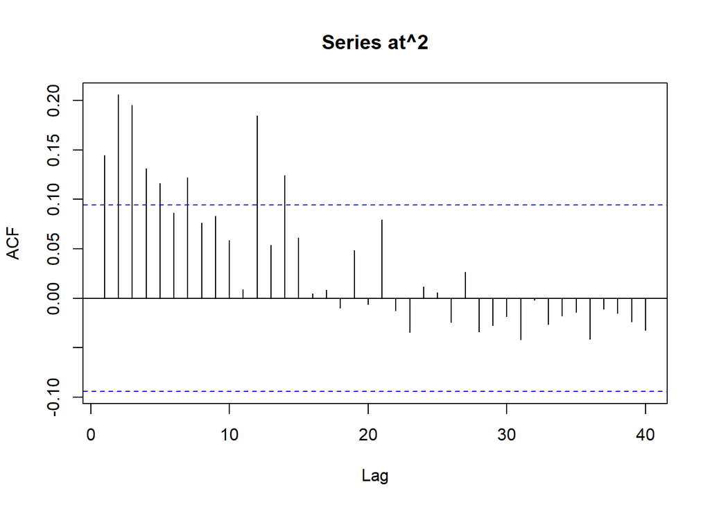

```r
at = logrtn_intc - mean(logrtn_intc)
acf(at^2, 40)
```

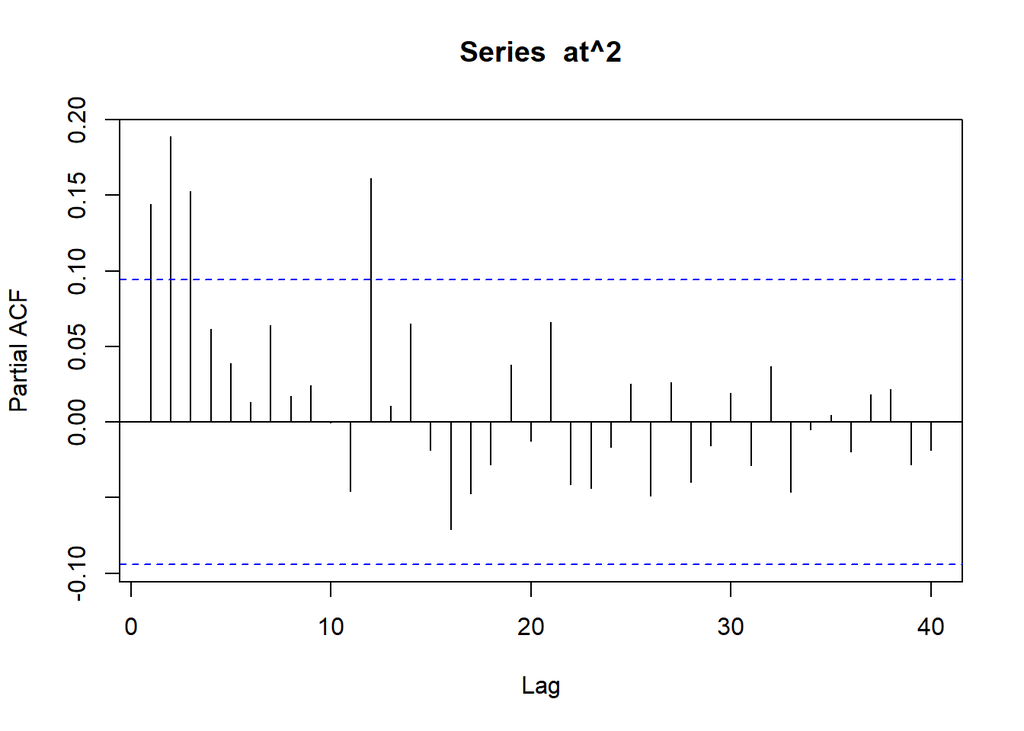

```r
pacf(at^2, 40)
```

```r
eacf(at^2)
```

```
## AR/MA
##   0 1 2 3 4 5 6 7 8 9 10 11 12 13
## 0 x x x x x o x o o o o  x  o  x
## 1 x o o o o o o o o o o  x  o  o
## 2 x x o o o o o o o o o  x  o  x
## 3 x x o o o o o o o o o  x  o  x
## 4 x x o x o o o o o o o  x  o  x
## 5 x o o x x o o o o o o  x  o  o
## 6 x x x x x o o o o o o  x  o  o
## 7 x x x x x o o o o o o  o  o  o
```

- $a^2_t$ ~ ARMA(1,1)

```r
# library(fGarch)
garch1.fit = garchFit(~ garch(1,1), data=logrtn_intc, trace=FALSE)
summary(garch1.fit)
```

```
##
## Title:
##  GARCH Modelling
##
## Call:
##  garchFit(formula = ~garch(1, 1), data = logrtn_intc, trace = FALSE)
##
## Mean and Variance Equation:
##  data ~ garch(1, 1)
## <environment: 0x0000000024ae62e8>
##  [data = logrtn_intc]
##
## Conditional Distribution:
##  norm
##
## Coefficient(s):
##         mu       omega      alpha1       beta1
## 0.01073352  0.00095445  0.08741989  0.85118414
##
## Std. Errors:
##  based on Hessian
##
## Error Analysis:
##         Estimate  Std. Error  t value Pr(>|t|)
## mu     0.0107335   0.0055289    1.941   0.0522 .
## omega  0.0009544   0.0003989    2.392   0.0167 *
## alpha1 0.0874199   0.0269810    3.240   0.0012 **
## beta1  0.8511841   0.0393702   21.620   <2e-16 ***
## ---
## Signif. codes:  0 '***' 0.001 '**' 0.01 '*' 0.05 '.' 0.1 ' ' 1
##
## Log Likelihood:
##  299.9705    normalized:  0.6943761
##
## Description:
##  Mon May 22 03:50:23 2023 by user: user
##
##
## Standardised Residuals Tests:
##                                 Statistic p-Value
##  Jarque-Bera Test   R    Chi^2  165.574   0
##  Shapiro-Wilk Test  R    W      0.9712087 1.626854e-07
##  Ljung-Box Test     R    Q(10)  8.267633  0.6027128
##  Ljung-Box Test     R    Q(15)  14.42612  0.4934871
##  Ljung-Box Test     R    Q(20)  15.13331  0.7687297
##  Ljung-Box Test     R^2  Q(10)  0.9891848 0.9998363
##  Ljung-Box Test     R^2  Q(15)  11.36596  0.7262473
##  Ljung-Box Test     R^2  Q(20)  12.68143  0.8906302
##  LM Arch Test       R    TR^2   10.70199  0.5546164
##
## Information Criterion Statistics:
##       AIC       BIC       SIC      HQIC
## -1.370234 -1.332563 -1.370403 -1.355361
```

- 1-step- to 5-step-ahead volatility forecasts

```r
predict(garch1.fit,n.ahead=5)
```

```
##   meanForecast meanError standardDeviation
## 1   0.01073352 0.1183990         0.1183990
## 2   0.01073352 0.1187943         0.1187943
## 3   0.01073352 0.1191642         0.1191642
## 4   0.01073352 0.1195104         0.1195104
## 5   0.01073352 0.1198344         0.1198344
```

## 3.

Consider the daily simple returns of the S&P composite index in the file d-gmsp9908.txt.

```r
gmsp = read.table("https://faculty.chicagobooth.edu/-/media/faculty/ruey-s-tsay/teaching/fts3/d-gmsp9908.txt", header=T)
head(gmsp)
```

```
##       date        gm        sp
## 1 19990104 -0.009607 -0.000919
## 2 19990105  0.052910  0.013582
## 3 19990106  0.046064  0.022140
## 4 19990107 -0.006405 -0.002051
## 5 19990108  0.032232  0.004221
## 6 19990111  0.074941 -0.008792
```

```r
sim_sp = gmsp$sp
```

1. Is there any ARCH effect in the simple return series?  
   Use 10 lags of the squared returns and 5% significance level to perform the test.

```r
at_2 = sim_sp - mean(sim_sp)
Box.test(at_2^2, lag=10, type="Ljung")
```

```
##
##  Box-Ljung test
##
## data:  at_2^2
## X-squared = 2097.7, df = 10, p-value < 2.2e-16
```

- there are ARCH effects in simple return with lag 10 in SP. (p-value < 0.05)
2. Build an adequate GARCH model for the simple return series.
- Serial correlation test Q(10) in SP

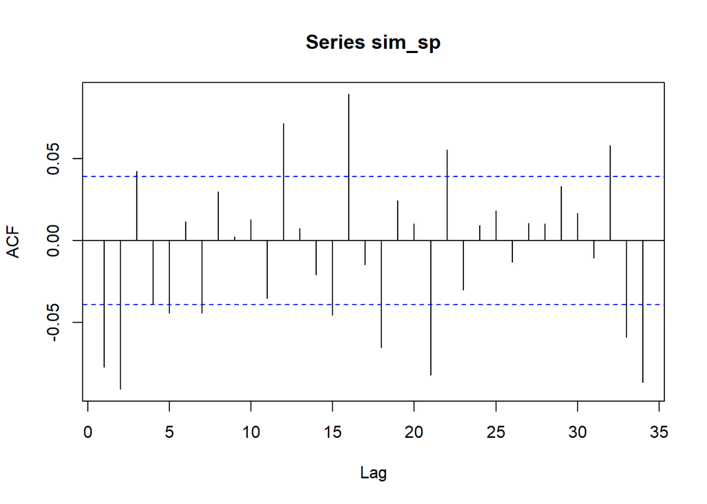

```r
acf(sim_sp)
```

```r
Box.test(sim_sp, lag=10, type='Ljung')
```

```
##
##  Box-Ljung test
##
## data:  sim_sp
## X-squared = 57.062, df = 10, p-value = 1.298e-08
```

- there are serial correlation of simple return of SP (p-value < 0.05)

```r
eacf(sim_sp)
```

```
## AR/MA
##   0 1 2 3 4 5 6 7 8 9 10 11 12 13
## 0 x x x o x o x o o o o  x  o  o
## 1 x x o o x o o o o o o  x  o  o
## 2 x x o x x o o o o o o  x  o  o
## 3 x x x o o o x o o o o  x  o  o
## 4 x x x x x o x o o o o  o  o  o
## 5 x x x x x o o o o o o  o  o  o
## 6 x x x x x x o o o o o  o  o  o
## 7 x x x x x x x o o o o  o  o  o
```

```r
m1 = arima(sim_sp, order = c(1,0,5))
m1
```

```
##
## Call:
## arima(x = sim_sp, order = c(1, 0, 5))
##
## Coefficients:
##           ar1     ma1      ma2      ma3      ma4      ma5  intercept
##       -0.9425  0.8656  -0.1748  -0.0557  -0.0106  -0.0775      0e+00
## s.e.   0.0237  0.0307   0.0264   0.0274   0.0265   0.0200      2e-04
##
## sigma^2 estimated as 0.0001745:  log likelihood = 7313.28,  aic = -14612.55
```

```r
rbind(m1$coef-2*sqrt(diag(m1$var.coef)),
      m1$coef+2*sqrt(diag(m1$var.coef)))
```

```
##             ar1       ma1        ma2         ma3         ma4         ma5
## [1,] -0.9899349 0.8041311 -0.2274694 -0.11052891 -0.06356003 -0.11746324
## [2,] -0.8950102 0.9270944 -0.1220469 -0.00096524  0.04228216 -0.03751075
##          intercept
## [1,] -0.0004530036
## [2,]  0.0003900543
```

```r
m2 = arima(sim_sp, order = c(1,0,5),
           fixed = c(NA,NA,NA,NA,0,NA,0))
m2
```

```
##
## Call:
## arima(x = sim_sp, order = c(1, 0, 5), fixed = c(NA, NA, NA, NA, 0, NA, 0))
##
## Coefficients:
##           ar1     ma1      ma2      ma3  ma4      ma5  intercept
##       -0.9425  0.8652  -0.1761  -0.0513    0  -0.0723          0
## s.e.   0.0236  0.0307   0.0265   0.0245    0   0.0155          0
##
## sigma^2 estimated as 0.0001745:  log likelihood = 7313.18,  aic = -14616.35
```

```r
Box.test(m2$residuals, lag=10, type='Ljung', fitdf = 6-1)
```

```
##
##  Box-Ljung test
##
## data:  m2$residuals
## X-squared = 4.5558, df = 5, p-value = 0.4725
```

- p-value>0.05，無序列相關，足夠
- EACF of $a_t^2$

```r
eacf(at_2^2)
```

```
## AR/MA
##   0 1 2 3 4 5 6 7 8 9 10 11 12 13
## 0 x x x x x x x x x x x  x  x  x
## 1 x x x x x o x x x x x  x  x  x
## 2 x x x x x o o x x o x  x  o  x
## 3 x o x x x o o x x o x  x  x  x
## 4 x x x x x o x o o o x  x  o  x
## 5 x x x x x x o x o o x  o  o  x
## 6 x x x x x x o x o o x  o  x  x
## 7 o x x x x o x o o o x  o  x  o
```

```r
ar(at_2^2)$order
```

```
## [1] 34
```

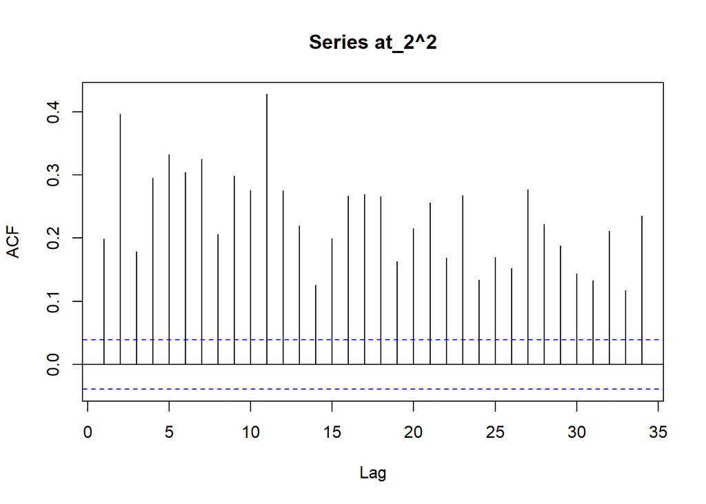

```r
acf(at_2^2)
```

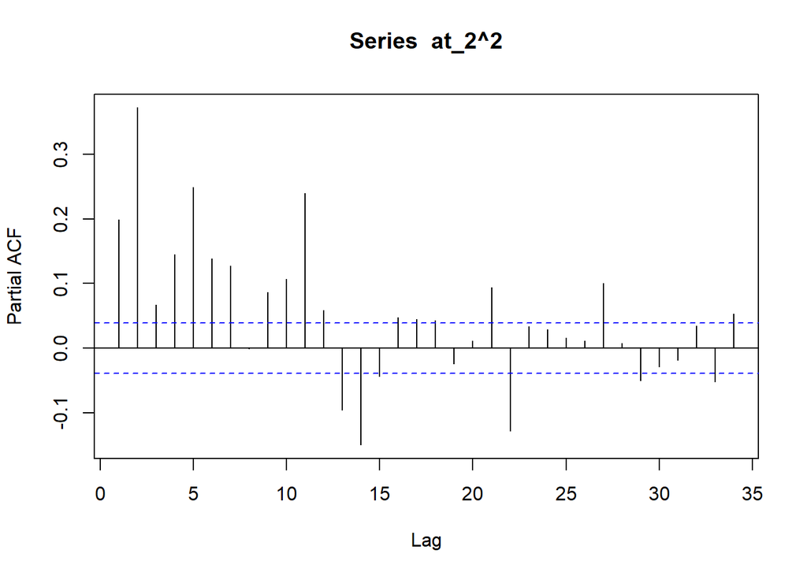

```r
pacf(at_2^2)
```

```r
arch2.fit = garchFit(~ arma(1,5) + garch(1,1), data=sim_sp, trace=FALSE)
summary(arch2.fit)
```

```
##
## Title:
##  GARCH Modelling
##
## Call:
##  garchFit(formula = ~arma(1, 5) + garch(1, 1), data = sim_sp,
##     trace = FALSE)
##
## Mean and Variance Equation:
##  data ~ arma(1, 5) + garch(1, 1)
## <environment: 0x000000002577c6e0>
##  [data = sim_sp]
##
## Conditional Distribution:
##  norm
##
## Coefficient(s):
##          mu          ar1          ma1          ma2          ma3          ma4
##  2.1398e-04   3.4746e-01  -4.1030e-01  -1.9827e-02   1.5066e-03  -1.2080e-02
##         ma5        omega       alpha1        beta1
## -4.8646e-02   1.0047e-06   7.1757e-02   9.2302e-01
##
## Std. Errors:
##  based on Hessian
##
## Error Analysis:
##          Estimate  Std. Error  t value Pr(>|t|)
## mu      2.140e-04   1.364e-04    1.569 0.116643
## ar1     3.475e-01   3.157e-01    1.100 0.271128
## ma1    -4.103e-01   3.156e-01   -1.300 0.193613
## ma2    -1.983e-02   3.054e-02   -0.649 0.516226
## ma3     1.507e-03   2.627e-02    0.057 0.954259
## ma4    -1.208e-02   2.290e-02   -0.528 0.597832
## ma5    -4.865e-02   2.372e-02   -2.051 0.040250 *
## omega   1.005e-06   2.940e-07    3.418 0.000632 ***
## alpha1  7.176e-02   9.124e-03    7.865 3.77e-15 ***
## beta1   9.230e-01   9.712e-03   95.035  < 2e-16 ***
## ---
## Signif. codes:  0 '***' 0.001 '**' 0.01 '*' 0.05 '.' 0.1 ' ' 1
##
## Log Likelihood:
##  7869.202    normalized:  3.128907
##
## Description:
##  Mon May 22 03:50:26 2023 by user: user
##
##
## Standardised Residuals Tests:
##                                 Statistic p-Value
##  Jarque-Bera Test   R    Chi^2  215.7639  0
##  Shapiro-Wilk Test  R    W      0.9895074 1.278278e-12
##  Ljung-Box Test     R    Q(10)  2.619176  0.9890229
##  Ljung-Box Test     R    Q(15)  11.60052  0.7089801
##  Ljung-Box Test     R    Q(20)  17.43692  0.6244478
##  Ljung-Box Test     R^2  Q(10)  14.54231  0.1496608
##  Ljung-Box Test     R^2  Q(15)  18.13752  0.2555046
##  Ljung-Box Test     R^2  Q(20)  19.78913  0.4711882
##  LM Arch Test       R    TR^2   15.48529  0.2159638
##
## Information Criterion Statistics:
##       AIC       BIC       SIC      HQIC
## -6.249862 -6.226681 -6.249894 -6.241449
```

```r
m4 = garchFit(~ arma(0,1) + garch(1,1), data=sim_sp, trace=FALSE)
summary(m4)
```

```
##
## Title:
##  GARCH Modelling
##
## Call:
##  garchFit(formula = ~arma(0, 1) + garch(1, 1), data = sim_sp,
##     trace = FALSE)
##
## Mean and Variance Equation:
##  data ~ arma(0, 1) + garch(1, 1)
## <environment: 0x00000000167e9a28>
##  [data = sim_sp]
##
## Conditional Distribution:
##  norm
##
## Coefficient(s):
##          mu          ma1        omega       alpha1        beta1
##  3.2801e-04  -6.1911e-02   9.9774e-07   7.1694e-02   9.2320e-01
##
## Std. Errors:
##  based on Hessian
##
## Error Analysis:
##          Estimate  Std. Error  t value Pr(>|t|)
## mu      3.280e-04   1.674e-04    1.959 0.050084 .
## ma1    -6.191e-02   2.183e-02   -2.835 0.004575 **
## omega   9.977e-07   2.976e-07    3.353 0.000799 ***
## alpha1  7.169e-02   9.210e-03    7.785 6.88e-15 ***
## beta1   9.232e-01   9.818e-03   94.031  < 2e-16 ***
## ---
## Signif. codes:  0 '***' 0.001 '**' 0.01 '*' 0.05 '.' 0.1 ' ' 1
##
## Log Likelihood:
##  7860.175    normalized:  3.125318
##
## Description:
##  Mon May 22 03:50:26 2023 by user: user
##
##
## Standardised Residuals Tests:
##                                 Statistic p-Value
##  Jarque-Bera Test   R    Chi^2  199.8719  0
##  Shapiro-Wilk Test  R    W      0.9903543 5.831966e-12
##  Ljung-Box Test     R    Q(10)  11.01959  0.355994
##  Ljung-Box Test     R    Q(15)  20.05439  0.1698561
##  Ljung-Box Test     R    Q(20)  26.33918  0.1548999
##  Ljung-Box Test     R^2  Q(10)  14.55338  0.1492131
##  Ljung-Box Test     R^2  Q(15)  18.61727  0.2316038
##  Ljung-Box Test     R^2  Q(20)  20.20714  0.4450413
##  LM Arch Test       R    TR^2   15.98609  0.1918742
##
## Information Criterion Statistics:
##       AIC       BIC       SIC      HQIC
## -6.246660 -6.235070 -6.246668 -6.242454
```

- $a_t$ : p-value>0.05，mean eq OK
- $a_t^2$ : pvalue>0.05，variance eq OK
3. Compute 1-step- to 4-step-ahead forecasts of the simple return  
   and its volatility based on the fitted model.
- 1-step- to 4-step-ahead volatility forecasts

```r
predict(m4, n.ahead=4)
```

```
##    meanForecast  meanError standardDeviation
## 1 -0.0006195901 0.02754699        0.02754699
## 2  0.0003280080 0.02754755        0.02749471
## 3  0.0003280080 0.02749534        0.02744260
## 4  0.0003280080 0.02744330        0.02739066
```